# 2016 Griffith Gridiron Rest of Season Analysis

## Week 12

*Alex Wagner, 11/22/2016*

The season is wrapping up, and with this week's results a majority of the teams are still in contest for the playoffs, but few have good odds. This report uses our previous performance and current standings to predict each team's chances of making the championship, winning the playoffs, or getting last place. This is accomplished through simulating millions of matchups based on the remaining season schedule.

## Environment Setup and Function Declarations

*Click the button below to see the methods used to generate this report*

```python
from IPython.display import HTML

HTML('''<script>
code_show=true;
function code_toggle() {
 if (code_show){
 $('div.input').hide();
 } else {
 $('div.input').show();
 }
 code_show = !code_show
}
$( document ).ready(code_toggle);
</script>
<form action="javascript:code_toggle()"><input type="submit" value="Click here to toggle on/off the raw code."></form>''')
```

```python
%matplotlib inline
import numpy as np
import scipy.stats
import matplotlib as plt
import seaborn as sns
import time
from collections import Counter
from bs4 import BeautifulSoup
import requests
import multiprocessing
LEAGUE_ID=402051
```

```python
# Load records from public ESPN league
url = 'http://games.espn.com/ffl/standings?leagueId={0}&seasonId=2016'.format(LEAGUE_ID)
r = requests.get(url)
r.raise_for_status()
soup = BeautifulSoup(r.content, "lxml")
```

```python
table = soup.find('table', {'id': 'xstandTbl_div0'})
rows = table.findAll('tr', {'class': 'sortableRow'})
records = dict()
COMPLETED_WEEKS = 0
for row in rows:
    pf = row.find('td', {'class': 'sortablePF'}).text
    record = row.find('td', {'class': 'sortableDIV'}).text
    teamName = row.find('td').a.text
    win, loss, tie = record.split('-')
    COMPLETED_WEEKS = int(win) + int(loss) + int(tie)
    records[teamName] = (int(win), int(loss), float(pf))
```

```python
# Load schedule from public ESPN league
url = 'http://games.espn.com/ffl/schedule?leagueId={0}'.format(LEAGUE_ID)
r = requests.get(url)
r.raise_for_status()
soup = BeautifulSoup(r.content, "lxml")
```

```python
rows = soup.find('table', {'class': "tableBody"}).findAll('tr', {'class': 'tableSubHead'})
schedule = dict()
for week, row in enumerate(rows, 1):
    matchups = list()
    matchup = row.findNextSibling()
    while(matchup.attrs['bgcolor'] != '#ffffff'):
        links = matchup.findAll('a')
        team1 = links[0].text
        team2 = links[1].text
        matchups.append((team1, team2))
        matchup = matchup.findNextSibling()
    schedule[week] = matchups
```

```python
def simulate_matchup(week, records, team1, team2):
    r1 = records[team1]
    r2 = records[team2]
    team1_mean = r1[2]/(week - 1)
    team2_mean = r2[2]/(week - 1)
    team1_score = round(np.random.normal(team1_mean, team1_mean / 10),2)
    team2_score = round(np.random.normal(team2_mean, team2_mean / 10),2)
    if team1_score > team2_score:
        a = 1
        b = 0
        winner = team1
        loser = team2
    elif team2_score > team1_score:
        a = 0
        b = 1
        winner = team2
        loser = team1
    else:
        return simulate_matchup(week, records, team1, team2)
    team1_result = (r1[0] + a, r1[1] + b, r1[2] + team1_score)
    team2_result = (r2[0] + b, r2[1] + a, r2[2] + team2_score)
    return { 'winner': winner,
             'loser': loser,
             'values': (team1_result, team2_result) }
```

```python
def simulate_season_rank():
    new_records = records.copy()
    for week in range(COMPLETED_WEEKS + 1,15):
        for matchup in schedule[week]:
            r = simulate_matchup(week, new_records, *matchup)
            new_records[matchup[0]], new_records[matchup[1]] = r['values']
    r = new_records
    return sorted(r, key=lambda x: (r[x][0], r[x][2]), reverse=True)
```

```python
def simulate_ROS():
    r = simulate_season_rank()
#     for i, team in enumerate(r, start=1):
#         outcomes[team].append(i)
    round_1 = (simulate_matchup(13, records, r[0], r[3])['winner'],
               simulate_matchup(13, records, r[1], r[2])['winner'])
    round_2 = simulate_matchup(13, records, *round_1)['winner']
    champion = round_2
    round_1 = (simulate_matchup(13, records, r[-4], r[-1])['loser'],
       simulate_matchup(13, records, r[-3], r[-2])['loser'])
    round_2 = simulate_matchup(13, records, *round_1)['loser']
    last = round_2
    return champion, last, r
```

```python
def simulate_n(chunk_size):
    outcomes = {team: [] for team in records.keys()}
    playoff_wins = Counter()
    last_place_finish = Counter()

    for _ in range(chunk_size):
        r = simulate_ROS()
        playoff_wins[r[0]] += 1
        last_place_finish[r[1]] += 1
        for i, team in enumerate(r[2], start=1):
            outcomes[team].append(i)
    return playoff_wins, last_place_finish, outcomes
```

## Simulating Remaining Matchups

```python
%%time
trials = 1000000
chunk_size = 10000
outcomes = {team: [] for team in records.keys()}
playoff_wins = Counter()
last_place_finish = Counter()

with multiprocessing.Pool(7) as p:
    results = p.map(simulate_n, [chunk_size] * (trials // chunk_size))

for r in results:
    playoff_wins += r[0]
    last_place_finish += r[1]
    for team, o in r[2].items():
        outcomes[team] += o

for team in outcomes:
    outcomes[team] = np.array(outcomes[team])
```

```
CPU times: user 1.35 s, sys: 206 ms, total: 1.56 s
Wall time: 27.5 s
```

```python
# %%time
# trials = 1000000
# outcomes = {team: [] for team in records.keys()}
# playoff_wins = Counter()
# last_place_finish = Counter()

# for _ in range(trials):
#     r = simulate_season_rank()
#     for i, team in enumerate(r, start=1):
#         outcomes[team].append(i)
#     round_1 = (simulate_matchup(13, records, r[0], r[3])['winner'],
#                simulate_matchup(13, records, r[1], r[2])['winner'])
#     round_2 = simulate_matchup(13, records, *round_1)['winner']
#     playoff_wins[round_2] += 1
#     round_1 = (simulate_matchup(13, records, r[-4], r[-1])['loser'],
#        simulate_matchup(13, records, r[-3], r[-2])['loser'])
#     round_2 = simulate_matchup(13, records, *round_1)['loser']
#     last_place_finish[round_2] += 1

# for team in outcomes:
#     outcomes[team] = np.array(outcomes[team])
```

## Results

### Distribution of Possible Outcomes

*Ranks left of the green line indicate outcomes where a team makes the playoffs. Ranks right of the red line indicate outcomes where a team will participate in the last-place playoffs.*

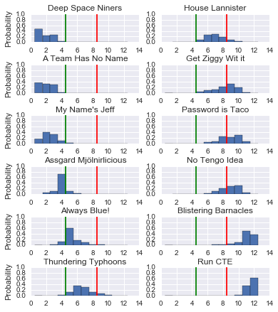

```python
teams = len(outcomes)
rows = teams // 2
f, axarr = plt.pyplot.subplots(rows, 2)
for i, team in enumerate(sorted(outcomes,
                                key=lambda x: scipy.stats.describe(outcomes[x]).mean)):
    row = i % rows
    column = i // rows
    axarr[row, column].hist(outcomes[team], bins=np.array(range(teams+1))+0.5, normed=True)
    if row == rows:
        axarr[row, column].set_xlabel('Rank')
    if column == 0:
        axarr[row, column].set_ylabel('Probability')
    axarr[row, column].set_title(team)
    x = 4.5
    axarr[row, column].plot([4.5, 4.5], [0, 1], 'g')
    x = teams - 3.5
    axarr[row, column].plot([x, x], [0, 1], 'r')
plt.pyplot.subplots_adjust(top = 1.5, hspace = 0.8)
```

### Overall Probability of Making the Playoffs

```python
overall_playoffs = dict()
for team in outcomes:
    percent = sum(outcomes[team] <= 4) / trials
    overall_playoffs[team] = percent
for team in sorted(outcomes,
                   key=lambda x: (overall_playoffs[x],
                                  scipy.stats.describe(outcomes[x]).mean * -1),
                   reverse=True):
    print('{0:<21} {1:7.2%}'.format(team + ':', overall_playoffs[team]))
```

```
A Team Has No Name:    99.93%
Deep Space Niners:     98.36%
My Name's Jeff:        98.07%
Assgard Mjölnirlicious:  87.18%
Always Blue!:          13.18%
Thundering Typhoons:    1.75%
House Lannister:        1.27%
Get Ziggy Wit it:       0.25%
No Tengo Idea:          0.01%
Password is Taco:       0.00%
Blistering Barnacles:   0.00%
Run CTE:                0.00%
```

### Overall Probability of Winning the Championship

```python
for team in sorted(playoff_wins, key=lambda x: playoff_wins[x], reverse=True):
    percent = playoff_wins[team] / trials
    print('{0:<21} {1:7.2%}'.format(team + ':', percent))
```

```
Deep Space Niners:     38.82%
A Team Has No Name:    28.24%
My Name's Jeff:        24.39%
Always Blue!:           4.64%
Assgard Mjölnirlicious:   3.77%
Thundering Typhoons:    0.08%
House Lannister:        0.04%
Get Ziggy Wit it:       0.00%
```

### Overall Probability of Last Place Contest

```python
overall_last_contest = dict()
for team in outcomes:
    percent = sum(outcomes[team] > teams - 4) / trials
    overall_last_contest[team] = percent
for team in sorted(outcomes,
                   key=lambda x: (overall_last_contest[x],
                                  scipy.stats.describe(outcomes[x]).mean * -1),
                   reverse=True):
    print('{0:<21} {1:7.2%}'.format(team + ':', overall_last_contest[team]))
```

```
Run CTE:               99.97%
Blistering Barnacles:  97.92%
No Tengo Idea:         66.50%
Password is Taco:      60.99%
Get Ziggy Wit it:      52.18%
House Lannister:       13.87%
Thundering Typhoons:    8.43%
Always Blue!:           0.13%
Deep Space Niners:      0.00%
A Team Has No Name:     0.00%
My Name's Jeff:         0.00%
Assgard Mjölnirlicious:   0.00%
```

### Overall Probability of Getting Last Place Trophy

```python
for team in sorted(last_place_finish, key=lambda x: last_place_finish[x], reverse=True):
    percent = last_place_finish[team] / trials
    print('{0:<21} {1:7.2%}'.format(team + ':', percent))
```

```
Run CTE:               64.57%
Blistering Barnacles:  22.18%
Get Ziggy Wit it:       6.41%
Password is Taco:       3.46%
No Tengo Idea:          2.66%
House Lannister:        0.48%
Thundering Typhoons:    0.23%
```

# Discussion

## Anyone's Game

There are three weeks left in the regular season, and 3/4 of our teams have at least some chance at making the championships (although this chance can be quite slim--sorry **No Tengo Idea**).

### A Sure Bet

Congratulations to **A Team Has No Name**, **My Name's Jeff**, and the **Deep Space Niners**. These teams have very good odds to make the playoffs, and don't need to worry much over the last three weeks of the season. At this point, the **Deep Space Niners** are the team to watch, currently projected as most likely to win the championship (38.82% of outcomes) on the backs of Le'Veon Bell and Melvin Gordon.

## Race to the Bottom

On the other end of our league, the contest to not finish last is also heating up. **Run CTE**, **Blistering Barnacles**, **Password is Taco**, **No Tengo Idea**, and **Get Ziggy Wit it** are more likely than not to end up here, each participating in the last-place bracket in at least 50% of simulated outcomes. This are looking particularly grim for **Run CTE** and **Blistering Barnacles**, both of whom have >97% chance of ending up in the bottom 4.

### Stay Vigilant

That doesn't mean that **House Lannister** and the **Thundering Typhoons** should be unconcerned. If the rest of the season goes poorly, they also have a very real chance of entering the bottom-four contest. Don't stop paying attention to your fantasy team if your championship hopes get dashed, as you could end up staring at the last place trophy for a year.